# Credit Card Fraud Detection

2024-09-27

This project entails building a Machine Learning model to detect fraudlent transactions. It utilizes the credit card data set sourced from Kaggle.

```r
creditCard <- read_csv("creditcard.csv")
glimpse(creditCard)
```

```
## Rows: 284,807
## Columns: 31
## $ Time   <dbl> 0, 0, 1, 1, 2, 2, 4, 7, 7, 9, 10, 10, 10, 11, 12, 12, 12, 13, 1…
## $ V1     <dbl> -1.3598071, 1.1918571, -1.3583541, -0.9662717, -1.1582331, -0.4…
## $ V2     <dbl> -0.07278117, 0.26615071, -1.34016307, -0.18522601, 0.87773675, …
## $ V3     <dbl> 2.53634674, 0.16648011, 1.77320934, 1.79299334, 1.54871785, 1.1…
## $ V4     <dbl> 1.37815522, 0.44815408, 0.37977959, -0.86329128, 0.40303393, -0…
## $ V5     <dbl> -0.33832077, 0.06001765, -0.50319813, -0.01030888, -0.40719338,…
## $ V6     <dbl> 0.46238778, -0.08236081, 1.80049938, 1.24720317, 0.09592146, -0…
## $ V7     <dbl> 0.239598554, -0.078802983, 0.791460956, 0.237608940, 0.59294074…
## $ V8     <dbl> 0.098697901, 0.085101655, 0.247675787, 0.377435875, -0.27053267…
## $ V9     <dbl> 0.3637870, -0.2554251, -1.5146543, -1.3870241, 0.8177393, -0.56…
## $ V10    <dbl> 0.09079417, -0.16697441, 0.20764287, -0.05495192, 0.75307443, -…
## $ V11    <dbl> -0.55159953, 1.61272666, 0.62450146, -0.22648726, -0.82284288, …
## $ V12    <dbl> -0.61780086, 1.06523531, 0.06608369, 0.17822823, 0.53819555, 0.…
```

[output cut: 18 more lines]

**Data Description**

- The dataset contains 31 columns and 284, 807 rows
- The rows represent the transactions made by European cardholders in September 2013.

*Features:*

- **Time:** Seconds elapsed between each transaction and the first transaction.
- **Amount:** Transaction amount
- 28 numerical variables resulting from PCA transformation
- **Class:** It is the Target Variable (Predictor Variable), contains 1 for fraudlent transactions and 0 otherwise

#### **Exploring the data**

```r
creditCard %>%
  count(Class) %>%
  mutate(percentage = round(n / sum(n) * 100, 2))
```

```
## # A tibble: 2 × 3
##   Class      n percentage
##   <dbl>  <int>      <dbl>
## 1     0 284315      99.8
## 2     1    492       0.17
```

The data is highly imbalanced. There are 284,315 (99.8%) non - fraudlent transactions and only 492 (0.17%) fraudlent transactions.

Credit card fraud datasets, including this one, are typically highly imbalanced because occurrences of fraud are rare compared to normal transactions.

*In the next sections, we explore effective strategies for handling this imbalance.*

**Correlation**

I calculated the correlation coefficients between the Class variable (predictor) and the other continuous variables

The correlation tells us how changes in the continuous variables are associated with the binary outcome (fraud or non-fraud).

For example, a positive correlation between Class and a continuous variable indicates that as the continuous variable increases, the probability of Class being 1 (fraud) also increases.

```r
corr <- cor(creditCard[, 1:30], creditCard$Class)
corr
```

```
##                 [,1]
## Time   -0.0123225709
## V1     -0.1013472986
## V2      0.0912886503
## V3     -0.1929608271
## V4      0.1334474862
## V5     -0.0949742990
## V6     -0.0436431607
## V7     -0.1872565915
## V8      0.0198751239
## V9     -0.0977326861
## V10    -0.2168829436
## V11     0.1548756447
## V12    -0.2605929249
## V13    -0.0045697788
## V14    -0.3025436958
## V15    -0.0042234023
## V16    -0.1965389403
## V17    -0.3264810672
## V18    -0.1114852539
## V19     0.0347830130
## V20     0.0200903242
## V21     0.0404133806
## V22     0.0008053175
## V23    -0.0026851557
## V24    -0.0072209067
## V25     0.0033077056
## V26     0.0044553975
## V27     0.0175797282
## V28     0.0095360409
## Amount  0.0056317530
```

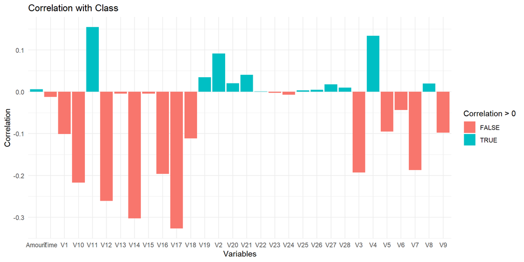

```r
# Correlation plot - using a bar chart

corr_df <- tibble(Variable = rownames(corr), Correlation = corr[, 1])

ggplot(corr_df, aes(x = Variable, y = Correlation, fill = Correlation > 0)) +
  geom_col() +
  labs(title = "Correlation with Class", x = "Variables", y = "Correlation") +
  theme_minimal()
```

Majority of the features have weak correlation with the Class variable

#### **Model Building**

Three classification models were developed to detect credit card fraud: Logistic Regression, Random Forest, and XGBoost. The process involved fitting, tuning, and evaluating each model to identify the best-performing one for the highly imbalanced dataset.

**Data Splitting**

```r
# The data was split into train and test sets using stratified sampling based on the Class variable

creditCard <- creditCard %>%
  mutate(Class = as.factor(Class)) %>%
  select(-Time)

set.seed(0231)
df_split <- initial_split(creditCard, strata = Class, prop = 0.75)
df_train <- training(df_split)
df_test <- testing(df_split)

df_train
```

```
## # A tibble: 213,605 × 30
##        V1      V2      V3      V4      V5      V6       V7      V8     V9
##     <dbl>   <dbl>   <dbl>   <dbl>   <dbl>   <dbl>    <dbl>   <dbl>  <dbl>
##  1 -1.36  -0.0728  2.54    1.38   -0.338   0.462   0.240    0.0987  0.364
##  2  1.19   0.266   0.166   0.448   0.0600 -0.0824 -0.0788   0.0851 -0.255
##  3 -0.966 -0.185   1.79   -0.863  -0.0103  1.25    0.238    0.377  -1.39
##  4 -1.16   0.878   1.55    0.403  -0.407   0.0959  0.593   -0.271   0.818
##  5  1.23   0.141   0.0454  1.20    0.192   0.273  -0.00516  0.0812  0.465
##  6 -0.644  1.42    1.07   -0.492   0.949   0.428   1.12    -3.81    0.615
##  7 -0.338  1.12    1.04   -0.222   0.499  -0.247   0.652    0.0695 -0.737
##  8  1.45  -1.18    0.914  -1.38   -1.97   -0.629  -1.42     0.0485 -1.72
##  9  0.385  0.616  -0.874  -0.0940  2.92    3.32    0.470    0.538  -0.559
## 10  1.07   0.288   0.829   2.71   -0.178   0.338  -0.0967   0.116  -0.221
## # ℹ 213,595 more rows
## # ℹ 21 more variables: V10 <dbl>, V11 <dbl>, V12 <dbl>, V13 <dbl>, V14 <dbl>,
## #   V15 <dbl>, V16 <dbl>, V17 <dbl>, V18 <dbl>, V19 <dbl>, V20 <dbl>,
## #   V21 <dbl>, V22 <dbl>, V23 <dbl>, V24 <dbl>, V25 <dbl>, V26 <dbl>,
## #   V27 <dbl>, V28 <dbl>, Amount <dbl>, Class <fct>
```

```r
df_test
```

```
## # A tibble: 71,202 × 30
##        V1     V2     V3     V4     V5      V6      V7      V8      V9     V10
##     <dbl>  <dbl>  <dbl>  <dbl>  <dbl>   <dbl>   <dbl>   <dbl>   <dbl>   <dbl>
##  1 -1.36  -1.34   1.77   0.380 -0.503  1.80    0.791   0.248  -1.51    0.208
##  2 -0.426  0.961  1.14  -0.168  0.421 -0.0297  0.476   0.260  -0.569  -0.371
##  3 -0.894  0.286 -0.113 -0.272  2.67   3.72    0.370   0.851  -0.392  -0.410
##  4  1.25  -1.22   0.384 -1.23  -1.49  -0.753  -0.689  -0.227  -2.09    1.32
##  5 -0.437  0.919  0.925 -0.727  0.916 -0.128   0.708   0.0880 -0.665  -0.738
##  6  0.962  0.328 -0.171  2.11   1.13   1.70    0.108   0.522  -1.19    0.724
##  7 -2.07  -0.121  1.32   0.410  0.295 -0.960   0.544  -0.105   0.476   0.149
##  8 -0.535  0.865  1.35   0.148  0.434  0.0870  0.693   0.180  -0.286  -0.482
##  9  1.11   0.169  0.517  1.33  -0.192  0.0195 -0.0318  0.118   0.0177  0.0449
## 10  1.39  -0.794  0.778 -0.865 -1.06   0.351  -1.19    0.0527 -0.304   0.577
## # ℹ 71,192 more rows
## # ℹ 20 more variables: V11 <dbl>, V12 <dbl>, V13 <dbl>, V14 <dbl>, V15 <dbl>,
## #   V16 <dbl>, V17 <dbl>, V18 <dbl>, V19 <dbl>, V20 <dbl>, V21 <dbl>,
## #   V22 <dbl>, V23 <dbl>, V24 <dbl>, V25 <dbl>, V26 <dbl>, V27 <dbl>,
## #   V28 <dbl>, Amount <dbl>, Class <fct>
```

**Data Preprocessing (Recipe)**

The data is highly imbalanced. Using the data set as it is may lead to poor performance in detecting one class.

The overwhelming majority of records belong to the non-fraudulent class (class 0), making up over 99% of the dataset.

Models trained on imbalanced data may prioritize accuracy on the majority class while neglecting the minority class (fraudulent transactions). This can result in poor performance in detecting fraud. Thus, we use resampling techniques such as SMOTE and Downsampling to overcome this challenge:

1. Oversampling techniques like SMOTE (Synthetic Minority Over-sampling Technique) artificially inflates the minority class by generating synthetic examples. However, this can lead to overfitting and the introduction of noise, especially in cases where the minority class is already sparsely represented.
2. Downsampling involves randomly reducing the number of samples in the majority class to balance it with the minority class. This approach helps mitigate the biases towards the majority class while maintaining the integrity of the dataset. By reducing the number of majority class samples to match the minority class, downsampling encourages the model to learn from both classes equally, improving its ability to accurately detect fraudulent transactions.

*Due to the huge data set and computational challenges, this project utilizes the downsampling resampling technique only*

```r
library(themis)

df_recipe <- recipe(Class ~ ., data = df_train) %>%
  step_downsample(Class, under_ratio = 1) %>%   # under_ratio = 1 is the default
  step_normalize(all_predictors())

prep(df_recipe) %>% bake(new_data = NULL)
```

```
## # A tibble: 704 × 30
##       V1     V2    V3      V4    V5       V6    V7       V8     V9     V10
##    <dbl>  <dbl> <dbl>   <dbl> <dbl>    <dbl> <dbl>    <dbl>  <dbl>   <dbl>
##  1 0.558 -1.40  0.293 -0.942  0.250  1.55    0.433 -0.00549 0.515  0.709
##  2 0.574 -0.606 0.583 -0.308  0.366  0.632   0.526 -0.0654  0.599  0.622
##  3 0.663 -0.625 0.664 -0.953  0.138 -0.0906  0.406 -0.119   0.0531 0.794
##  4 0.278 -0.375 0.670 -0.878  0.453  0.613   0.496  0.0570  0.502  0.428
##  5 0.637 -0.399 0.701  0.0256 0.317  0.386   0.454 -0.0816  0.419  0.778
##  6 0.287 -0.275 0.632 -1.41   0.167  0.233   0.149 -1.27    0.968  0.00743
##  7 0.621 -0.499 0.793 -0.329  0.172  0.425   0.397 -0.0587  0.758  0.612
##  8 0.661 -0.555 0.388 -0.956  0.855  2.37    0.394  0.0874  0.686  0.588
##  9 0.182 -0.332 0.898 -1.53   0.154 -0.00802 0.468  0.0422  0.934  0.239
## 10 0.773 -0.605 0.207 -0.628  0.546 -0.00408 0.620 -0.188   0.736  0.639
## # ℹ 694 more rows
## # ℹ 20 more variables: V11 <dbl>, V12 <dbl>, V13 <dbl>, V14 <dbl>, V15 <dbl>,
## #   V16 <dbl>, V17 <dbl>, V18 <dbl>, V19 <dbl>, V20 <dbl>, V21 <dbl>,
## #   V22 <dbl>, V23 <dbl>, V24 <dbl>, V25 <dbl>, V26 <dbl>, V27 <dbl>,
## #   V28 <dbl>, Amount <dbl>, Class <fct>
```

**Model Specification**

```r
# logistic model

logistic_spec <- logistic_reg() %>%
  set_engine("glm") %>%
  set_mode("classification")


# Random forest model

rf_spec <-
  rand_forest(trees = 1000, min_n = tune(), mtry = tune()) %>%
  set_engine("ranger", importance = "impurity") %>%
  set_mode("classification")

# xgboost model

xgb_spec <-
  boost_tree(trees = 1000, mtry = tune(), min_n = tune(), learn_rate = tune(),
             loss_reduction = tune(), sample_size = tune()) %>%
  set_engine("xgboost") %>%
  set_mode("classification")
```

**Workflow set**

```r
df_wfs <-
  workflow_set(preproc = list(rec = df_recipe),
               models = list(logistic = logistic_spec,
                             rf = rf_spec,
                             xgb = xgb_spec))

df_wfs
```

```
## # A workflow set/tibble: 3 × 4
##   wflow_id     info             option    result
##   <chr>        <list>           <list>    <list>
## 1 rec_logistic <tibble [1 × 4]> <opts[0]> <list [0]>
## 2 rec_rf       <tibble [1 × 4]> <opts[0]> <list [0]>
## 3 rec_xgb      <tibble [1 × 4]> <opts[0]> <list [0]>
```

```r
df_wfs <- df_wfs %>%
  mutate(wflow_id = str_replace_all(wflow_id, "rec_", ""))
```

**Model Tuning**

```r
# Resample folds

set.seed(3287)
df_folds <- vfold_cv(df_train, strata = Class)
df_folds
```

```
## #  10-fold cross-validation using stratification
## # A tibble: 10 × 2
##    splits                 id
##    <list>                 <chr>
##  1 <split [192244/21361]> Fold01
##  2 <split [192244/21361]> Fold02
##  3 <split [192244/21361]> Fold03
##  4 <split [192244/21361]> Fold04
##  5 <split [192244/21361]> Fold05
##  6 <split [192245/21360]> Fold06
##  7 <split [192245/21360]> Fold07
##  8 <split [192245/21360]> Fold08
##  9 <split [192245/21360]> Fold09
## 10 <split [192245/21360]> Fold10
```

```r
library(finetune)

doParallel::registerDoParallel()

ctrl = control_race(save_pred = TRUE,
                    verbose_elim = TRUE)

ctrl
```

```
## Racing method control object
```

```r
df_race <- df_wfs %>%
  workflow_map(
    "tune_race_anova",
    seed = 1234,
    resamples = df_folds,
    grid = 15,   # # Evaluate 15 different hyperparameter combinations
    control = ctrl
  )
```

```
## ℹ Evaluating against the initial 3 burn-in resamples.
## i Creating pre-processing data to finalize unknown parameter: mtry
##
## ℹ Racing will maximize the roc_auc metric.
## ℹ Resamples are analyzed in a random order.
## ℹ Fold08: 10 eliminated; 5 candidates remain.
##
## ℹ Fold10: 0 eliminated; 5 candidates remain.
##
## ℹ Fold03: 0 eliminated; 5 candidates remain.
##
## ℹ Fold02: 1 eliminated; 4 candidates remain.
##
## ℹ Fold04: All but one parameter combination were eliminated.
##
## ℹ Evaluating against the initial 3 burn-in resamples.
## i Creating pre-processing data to finalize unknown parameter: mtry
##
## ℹ Racing will maximize the roc_auc metric.
## ℹ Resamples are analyzed in a random order.
## ℹ Fold08: 4 eliminated; 11 candidates remain.
##
## ℹ Fold10: 7 eliminated; 4 candidates remain.
##
## ℹ Fold03: 2 eliminated; 2 candidates remain.
##
## ℹ Fold02: 0 eliminated; 2 candidates remain.
##
## ℹ Fold04: 0 eliminated; 2 candidates remain.
##
## ℹ Fold06: 0 eliminated; 2 candidates remain.
##
## ℹ Fold09: 0 eliminated; 2 candidates remain.
```

```r
df_race
```

```
## # A workflow set/tibble: 3 × 4
##   wflow_id info             option    result
##   <chr>    <list>           <list>    <list>
## 1 logistic <tibble [1 × 4]> <opts[3]> <rsmp[+]>
## 2 rf       <tibble [1 × 4]> <opts[3]> <race[+]>
## 3 xgb      <tibble [1 × 4]> <opts[3]> <race[+]>
```

**Model Selection**

```r
df_race %>% collect_metrics()
```

```
## # A tibble: 12 × 9
##    wflow_id .config        preproc model .metric .estimator   mean     n std_err
##    <chr>    <chr>          <chr>   <chr> <chr>   <chr>       <dbl> <int>   <dbl>
##  1 logistic Preprocessor1… recipe  logi… accura… binary     0.947     10 5.46e-3
##  2 logistic Preprocessor1… recipe  logi… brier_… binary     0.0470    10 5.87e-3
##  3 logistic Preprocessor1… recipe  logi… roc_auc binary     0.956     10 1.06e-2
##  4 rf       Preprocessor1… recipe  rand… accura… binary     0.976     10 1.13e-3
##  5 rf       Preprocessor1… recipe  rand… brier_… binary     0.0330    10 6.55e-4
##  6 rf       Preprocessor1… recipe  rand… roc_auc binary     0.979     10 4.03e-3
##  7 xgb      Preprocessor1… recipe  boos… accura… binary     0.972     10 1.49e-3
##  8 xgb      Preprocessor1… recipe  boos… brier_… binary     0.0268    10 7.01e-4
##  9 xgb      Preprocessor1… recipe  boos… roc_auc binary     0.979     10 4.18e-3
## 10 xgb      Preprocessor1… recipe  boos… accura… binary     0.973     10 9.42e-4
## 11 xgb      Preprocessor1… recipe  boos… brier_… binary     0.0290    10 5.47e-4
## 12 xgb      Preprocessor1… recipe  boos… roc_auc binary     0.979     10 3.90e-3
```

```r
df_race %>% rank_results() %>%
  filter(.metric == "roc_auc")
```

```
## # A tibble: 4 × 9
##   wflow_id .config          .metric  mean std_err     n preprocessor model  rank
##   <chr>    <chr>            <chr>   <dbl>   <dbl> <int> <chr>        <chr> <int>
## 1 xgb      Preprocessor1_M… roc_auc 0.979 0.00390    10 recipe       boos…     1
## 2 rf       Preprocessor1_M… roc_auc 0.979 0.00403    10 recipe       rand…     2
## 3 xgb      Preprocessor1_M… roc_auc 0.979 0.00418    10 recipe       boos…     3
## 4 logistic Preprocessor1_M… roc_auc 0.956 0.0106     10 recipe       logi…     4
```

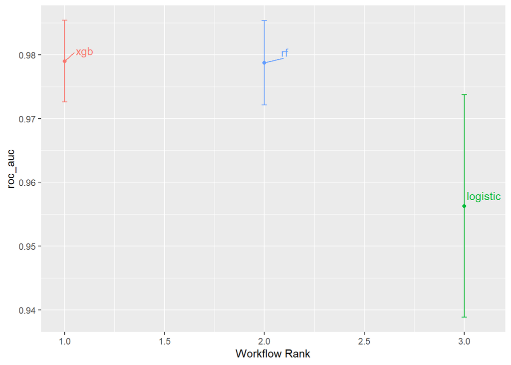

```r
# Plot
autoplot(df_race,
         rank_metric = "roc_auc",
         metric = "roc_auc",
         select_best = TRUE) +
  ggrepel::geom_text_repel(aes(label = wflow_id), nudge_x = 0.1, nudge_y = 1/600) +
  theme(legend.position = "none")
```

```r
# Extract the best results and fit the final model

best_results <- df_race %>%
  extract_workflow_set_result("xgb") %>%
  select_best(metric = "roc_auc")

best_results
```

```
## # A tibble: 1 × 6
##    mtry min_n learn_rate loss_reduction sample_size .config
##   <int> <int>      <dbl>          <dbl>       <dbl> <chr>
## 1    13    10    0.00527    0.000000176       0.871 Preprocessor1_Model15
```

```r
df_fit <- df_race %>%
  extract_workflow("xgb") %>%
  finalize_workflow(best_results) %>%
  last_fit(df_split)

df_fit
```

```
## # Resampling results
## # Manual resampling
## # A tibble: 1 × 6
##   splits                 id            .metrics .notes   .predictions .workflow
##   <list>                 <chr>         <list>   <list>   <list>       <list>
## 1 <split [213605/71202]> train/test s… <tibble> <tibble> <tibble>     <workflow>
```

**Model Evaluation**

```r
df_fit %>% collect_metrics()
```

```
## # A tibble: 3 × 4
##   .metric     .estimator .estimate .config
##   <chr>       <chr>          <dbl> <chr>
## 1 accuracy    binary        0.973  Preprocessor1_Model1
## 2 roc_auc     binary        0.986  Preprocessor1_Model1
## 3 brier_class binary        0.0286 Preprocessor1_Model1
```

```r
# Confusion matrix

df_fit %>%
  collect_predictions() %>%
  conf_mat(Class, .pred_class)
```

```
##           Truth
## Prediction     0     1
##          0 69133    12
##          1  1929   128
```

```r
# Performance metrics

df_fit %>%
  collect_predictions() %>%
  conf_mat(Class, .pred_class) %>% summary()
```

```
## # A tibble: 13 × 3
##    .metric              .estimator .estimate
##    <chr>                <chr>          <dbl>
##  1 accuracy             binary        0.973
##  2 kap                  binary        0.113
##  3 sens                 binary        0.973
##  4 spec                 binary        0.914
##  5 ppv                  binary        1.00
##  6 npv                  binary        0.0622
##  7 mcc                  binary        0.235
##  8 j_index              binary        0.887
##  9 bal_accuracy         binary        0.944
## 10 detection_prevalence binary        0.971
## 11 precision            binary        1.00
## 12 recall               binary        0.973
## 13 f_meas               binary        0.986
```

**Variable Importance**

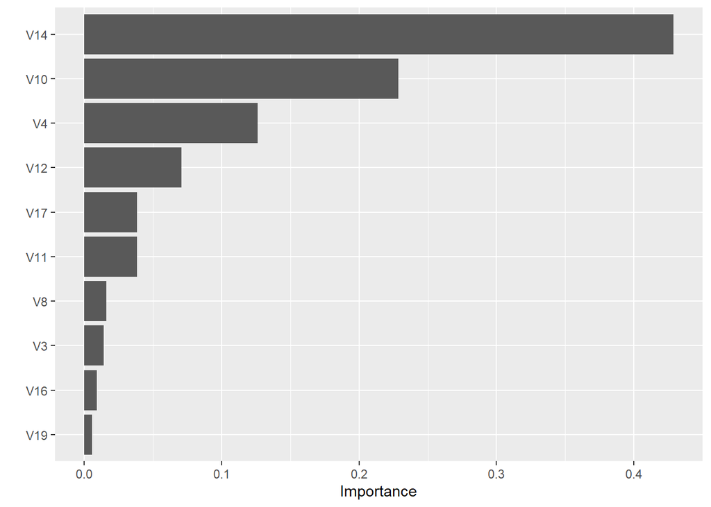

```r
library(vip)
df_fit %>%
  extract_fit_engine() %>%
  vip()
```

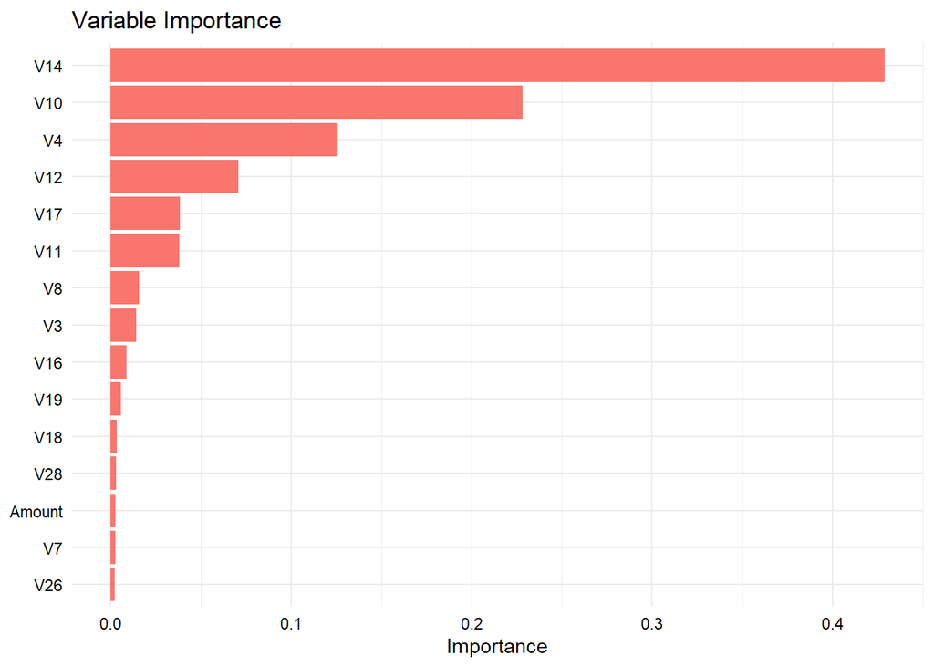

```r
extract_fit_engine(df_fit) %>%
  vi() %>%
  slice_max(Importance, n = 15) %>%
  ggplot(aes(fct_reorder(Variable, Importance), Importance, fill = "midnightblue")) +
  geom_col() +
  coord_flip() +
  labs(y = "Importance", x = NULL, title = "Variable Importance") +
  theme_minimal() +
  theme(legend.position = "none") +
  theme(axis.text = element_text(color = "black"))
```

The most important variables in the model were V14, V10, and V4, which significantly influenced its ability to detect fraudulent transactions. These features contributed the most to the model’s performance, enhancing its accuracy and detection capabilities.

Since fraud detection models are more concerned with identifying fraud cases correctly, focusing on reducing false negatives - fraudulent transactions classified as non-fraudulent (improving NPV and specificity) is advised.